# Weather accurately predicts clinical malaria in Magude

MALTEM

May 16, 2017

# Executive summary

A machine learning model (using a “random forest” algorithm), trained on weather data (precipitation, temperature variation) and MDA data (pre/during MALTEM dummy) can predict the number of clinical malaria cases in Magude with a fairly high degree of accuracy.

# Data sources

## Weather

We use weather from the Maputo airport weather station, obtained through the `get_data` function in the publicly available `cism` package in R.

## Surveillance

We use BES data from the Mozambican Ministry of Health. We have this data on record through the end of 2016.

# Feature generation

Our weather data contain only 4 variables of interest: precipitation, mean temperature, maximum temperature, and minimum temperature. However, we generate lagged and aggregated features for periods of interest. These include the following (hopefully self-explanatory) variables:

```
 [1] "avg_temp_from_100_to_20_days_ago"
 [2] "avg_temp_from_100_to_40_days_ago"
 [3] "avg_temp_from_100_to_60_days_ago"
 [4] "avg_temp_from_100_to_80_days_ago"
 [5] "avg_temp_from_40_to_20_days_ago"
 [6] "avg_temp_from_60_to_20_days_ago"
 [7] "avg_temp_from_60_to_40_days_ago"
 [8] "avg_temp_from_80_to_20_days_ago"
 [9] "avg_temp_from_80_to_40_days_ago"
[10] "avg_temp_from_80_to_60_days_ago"
[11] "dry_days_from_100_to_20_days_ago"
[12] "dry_days_from_100_to_40_days_ago"
[13] "dry_days_from_100_to_60_days_ago"
[14] "dry_days_from_100_to_80_days_ago"
[15] "dry_days_from_40_to_20_days_ago"
```

[output cut: 65 more lines]

We intentionally blind the model to (a) any historical case data, and (b) any weather data in the previous 20 days. Thanks to the latter, we are able to predict 20 days in advance (since the model requires only data greater than 20 days old).

# Methods

We run a random forest regression with all features. Random forest has an advantage over linear regression because (a) it better handles thresholds, (b) it better handles interactions.

# Results

The below plot shows the number of true cases (per BES data) and predicted cases (per the algorithm) over the last 7 years.

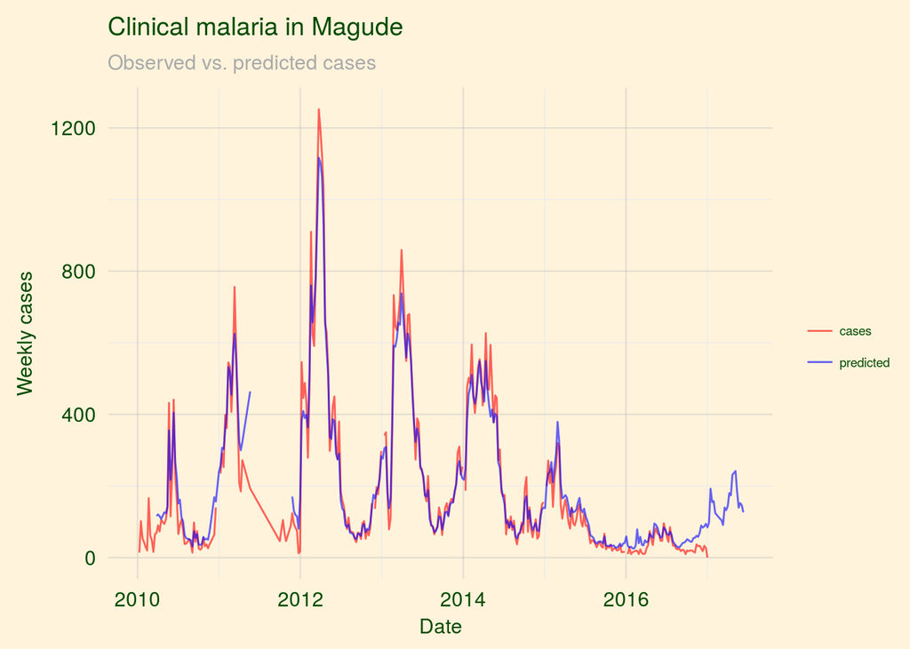

Also note that this model is *completely* blind to data after 2016-09-01. Even wihtout any epi information, it predicts a startling rise in malaria cases in Magude during the month of April and May, which we have observed in reality.

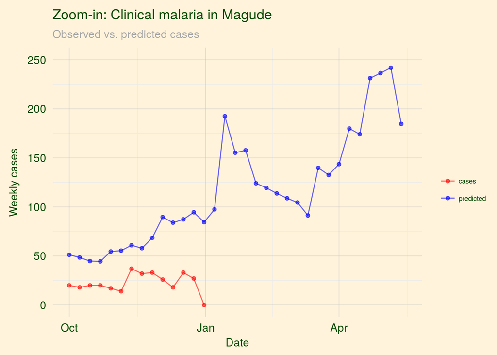

The below table shows the the number of predicted and observed cases by week.

|  | date | cases | predicted |
| --- | --- | --- | --- |
| 1 | 2017-06-10 |  | 126 |
| 2 | 2017-06-03 |  | 146 |
| 3 | 2017-05-27 |  | 152 |
| 4 | 2017-05-20 |  | 140 |
| 5 | 2017-05-13 |  | 185 |
| 6 | 2017-05-06 |  | 242 |
| 7 | 2017-04-29 |  | 236 |
| 8 | 2017-04-22 |  | 231 |
| 9 | 2017-04-15 |  | 174 |
| 10 | 2017-04-08 |  | 180 |

[output cut: 330 more lines]

The below chart shows the predicted and observed cases for each year separately.

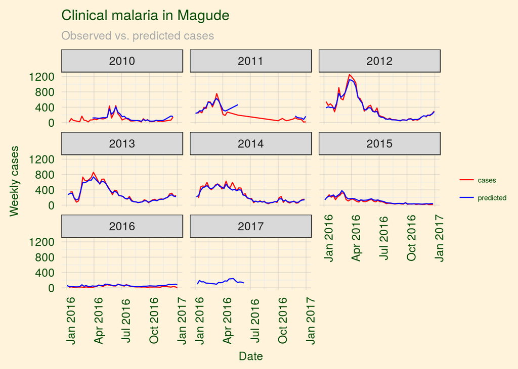

The below chart reflects model accuracy / stability. The model performs fairly well across both low and high incidence periods. The color of each point reflects whether this period was in the training sample or not (ie, we are more concerned about “out of sample” performance than in sample). Note that this does not include any data from 2017.

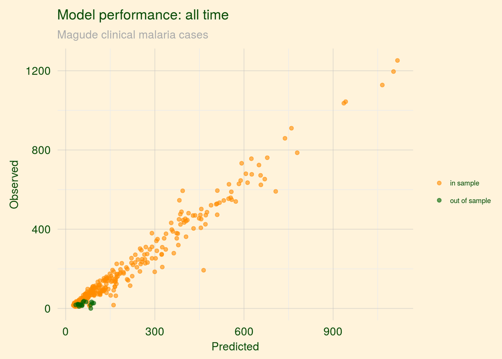

# Discussion

## Limitations

- The model is still showing weakness in the intervention period (it over-predicts systematically).
- The model appears to have incorrectly predicted a January 2017 spike; this may be correctable by better incorporation of MDA timing (currently using only a dummy).
- No concept of confidence-bounding has yet been introduced.